# E-commerce Business Report

A practice example of a pyspark business report

Author

Dennis Feyerabend

Published

December 1, 2025

Abstract

The project analyzes the e-commerce data of a fictitious company to identify insights and key trends. The report is written in Quarto and uses a custom theme (Arrakis Night). The primary purpose of the report was to practice pyspark and business reporting.

# 1 E-Commerce Business Report

## 1.1 Data overview:

The data for this report was created with the script `generate_bigdata.py` and stored in the `data` folder. The dataset used is `ecommerce_5m.csv`, containing **5 million rows**.

### 1.1.1 Column Overview

[output not shown]

## 1.2 Goals of analyses

The report aims to answer the following questions:

1. Which country is most important for business?
2. Which products generate the most revenue?
3. Which customers are most important and how are they characterized?

# 2 Revenue per country

## 2.1 Insights: Country revenue contribution over the last two years:

| country | order_volume | total_revenue_mill | avg_revenue | revenue_percent |
| --- | --- | --- | --- | --- |
| Germany | 2250568 | 1,287.82 | 572.22 | 45.04 |
| Austria | 750533 | 428.72 | 571.21 | 14.99 |
| Switzerland | 599950 | 343.80 | 573.05 | 12.02 |
| Netherlands | 499471 | 285.42 | 571.44 | 9.98 |
| Belgium | 399549 | 228.03 | 570.71 | 7.98 |
| France | 300321 | 171.71 | 571.76 | 6.01 |
| Poland | 199608 | 113.76 | 569.93 | 3.98 |

## 2.2 Insights: Yearly country revenue:

- There are no noticable changes in revenue contribution between countries for the years 2023 and 2024.

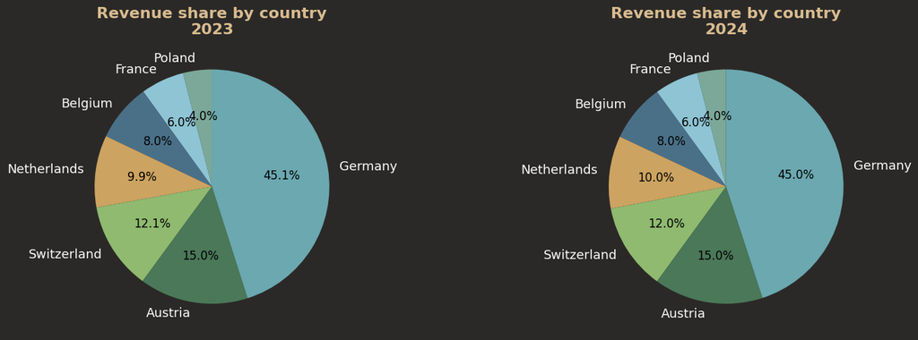

## 2.3 Insights: Monthly country revenue for 2024:

- Revenue contribution between countries has been stable over the last year.

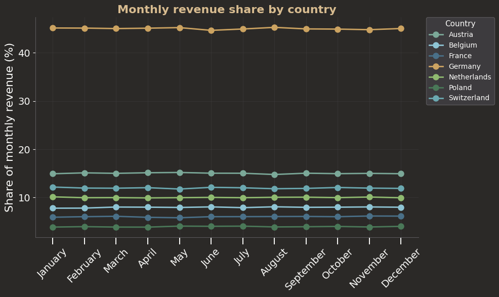

## 2.4 Key insight:

- The company revenue is heavily dependent on the German market. Diversification is needed.

# 3 Revenue per Product Category

## 3.1 Insights: Product revenue contribution

- Electronics dominate total revenue generation (53.5%) but expose the business to concentration risk. Any sector downturn in electronics would heavily impact total revenue.
- Lower-performing categories represent only ~7% of revenue. These categories could be candidates for portfolio optimization, consolidation, or targeted growth strategies

| product_category | order_volume | total_revenue_mill | avg_revenue | revenue_percent |
| --- | --- | --- | --- | --- |
| Electronics | 1248965 | 1,530.18 | 1,225.16 | 53.52 |
| Home & Garden | 750846 | 459.77 | 612.33 | 16.08 |
| Fashion | 999124 | 367.59 | 367.91 | 12.86 |
| Sports | 600309 | 299.19 | 498.39 | 10.46 |
| Toys | 300645 | 74.84 | 248.94 | 2.62 |
| Beauty | 400233 | 73.56 | 183.80 | 2.57 |
| Books | 499513 | 34.38 | 68.83 | 1.20 |
| Food | 200365 | 19.74 | 98.54 | 0.69 |

## 3.2 Insights: Product revenue contribution over the last two years (2023 + 2024):

- There are no noticable changes revenue contribution between products between the years 2023 and 2024.

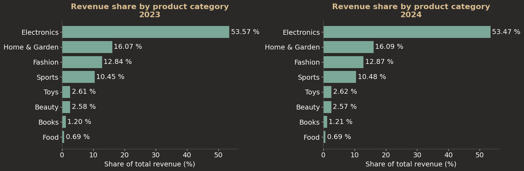

## 3.3 Monthly product revenue contribution for 2024:

- Product category revenue shares are highly stable throughout the year, indicating predictable customer demand and low volatility across categories.

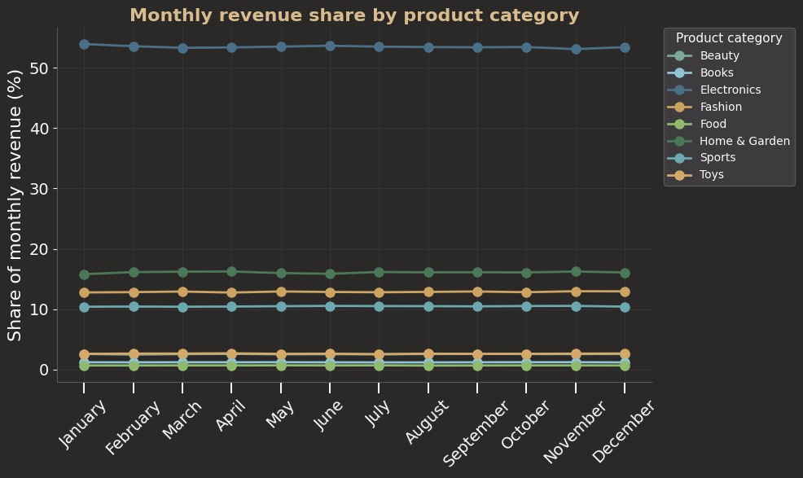

## 3.4 Key insight:

- The company revenue is heavily dependent on Electronics. Diversification is recommended.

# 4 Top products per country

## 4.1 Insights: Top revenue generating products per country:

- The top products are the same between countries
- The most profitable products are Electronics, followed by Home & Garden articles and then Fasion

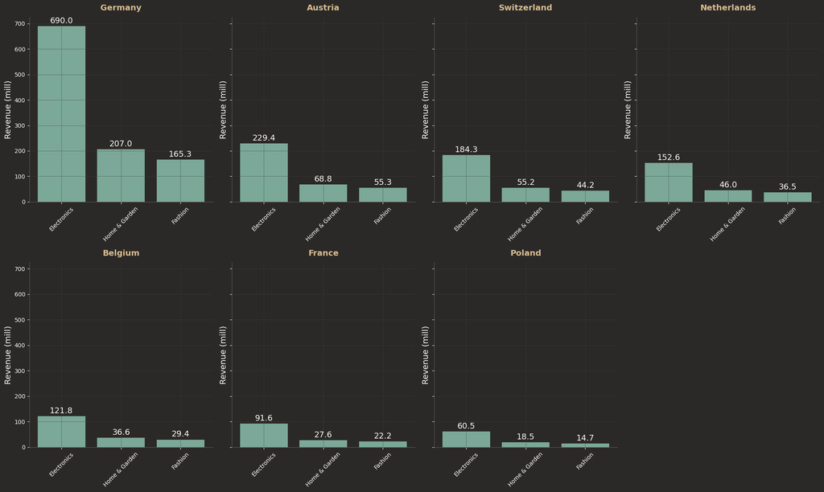

# 5 Customer analysis

## 5.1 Insights: Top customers:

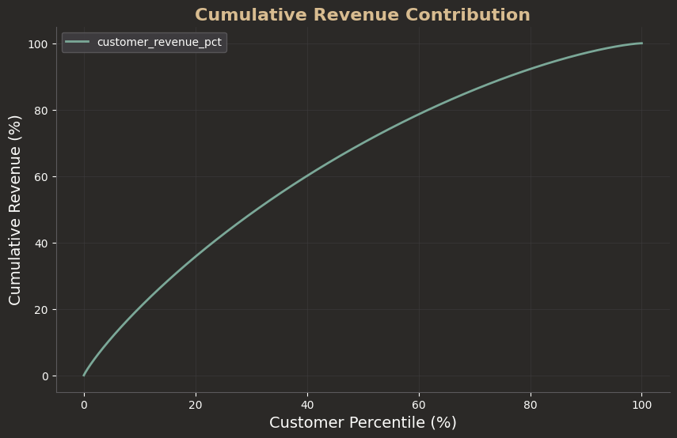

# 6 Summary of Results

## 6.1 Key Insights

- Revenue is concentrated in a small set of countries with Germany being the most important (followed by Austria, Switzerland and Netherlands).
- A few product categories account for the majority of total sales.
- Category and country contributions remain stable over time, indicating predictable customer demand.
- The same products consistently appear as top revenue drivers within each country.
- There is no distinct small group of “VP customers”, instead the majority of customers contribute meaningfully to total revenue.

# 7 Recommendations

- Strengthen marketing and promotional strategies in the top-performing countries.
- Evaluate opportunities to expand in mid-tier markets with growing potential.
- Prioritize inventory planning for high-impact product categories and top-selling items.